# Майнор "Интеллектуальный анализ данных"

# Курс "Современные методы машинного обучения"

# Лабораторная работа №2. Object Detection.

## Data

```python
!pip3 install --upgrade google-api-python-client
```

```
     |████████████████████████████████| 7.9 MB 1.1 MB/s eta 0:00:01
     |████████████████████████████████| 109 kB 9.0 MB/s eta 0:00:01
     |████████████████████████████████| 155 kB 12.1 MB/s eta 0:00:01
     |████████████████████████████████| 96 kB 3.1 MB/s eta 0:00:011
     |████████████████████████████████| 207 kB 9.8 MB/s eta 0:00:01
     |████████████████████████████████| 1.0 MB 9.3 MB/s eta 0:00:01
```

```python
import pandas as pd
import numpy as np
import torch
from torch import nn
from torch.nn import functional as F
from torch.utils.data import Dataset, DataLoader, random_split
import glob
import cv2
import os
import torchvision
import matplotlib.pyplot as plt
from sklearn.metrics import auc
import torchvision
from torchvision.models.detection.faster_rcnn import FastRCNNPredictor
from torchvision.models.detection.faster_rcnn import fasterrcnn_mobilenet_v3_large_320_fpn
from torchvision.models.detection.faster_rcnn import fasterrcnn_mobilenet_v3_large_fpn
from torchvision.models.detection.faster_rcnn import fasterrcnn_resnet50_fpn
from torchvision.models.detection import ssd300_vgg16, retinanet_resnet50_fpn
from torchvision.models.detection import _utils as det_utils
import matplotlib.patches as patches
from sklearn.model_selection import train_test_split
import torchvision.models as models
```

Install library for processing the labeling

```
pip install xmltodict
```

```python
!pip3 install xmltodict
```

```python
import xmltodict, json, copy
```

```python
import warnings
warnings.filterwarnings("ignore")
```

В этом задании потребуется обучить детектор фруктов на изображении. Данные находятся в архиве `data.zip`. Данные уже поделены на train и test.

Датасет для трех классов.

```python
device = torch.device("cuda" if torch.cuda.is_available() else "cpu")
print(device)
```

```
cuda
```

```python
def to_device(data, device):
    if isinstance(data, dict):
        return dict((k, to_device(v, device)) for k, v in data.items())
    if isinstance(data, (list, tuple)):
        return [to_device(x, device) for x in data]
    return data.to(device, non_blocking=True)
```

```python
class FruitDataset(Dataset):
    def __init__(self, data_dir, transform=None, classific=True):
        self.images = []
        self.annotations = []
        self.transform = transform
        for annotation in glob.glob(data_dir + "/*xml"):
            image_fname = os.path.splitext(annotation)[0] + ".jpg"
            self.images.append(cv2.cvtColor(cv2.imread(image_fname), cv2.COLOR_BGR2RGB))
            with open(annotation) as f:
                annotation_dict = xmltodict.parse(f.read())
            bboxes = []
            labels = []
            objects = annotation_dict["annotation"]["object"]
            if not isinstance(objects, list):
                objects = [objects]
            for obj in objects:
                bndbox = obj["bndbox"]
                bbox = [bndbox["xmin"], bndbox["ymin"], bndbox["xmax"], bndbox["ymax"]]
                bbox = list(map(int, bbox))
                bboxes.append(torch.tensor(bbox))
                tags = {"apple": 53, "orange": 55, "banana": 52}
                if classific:
                    labels.append(tags[obj["name"]])
                else:
                    labels.append(1)
            self.annotations.append(
                {"boxes": torch.stack(bboxes).float(),
                 "labels": torch.tensor(labels)})

    def __getitem__(self, i):
        if self.transform:
            res = self.transform(self.images[i])
            bboxes=self.annotations[i]["boxes"]
            labels=self.annotations[i]["labels"]
            return res, {
                "boxes": torch.tensor(bboxes),
                "labels": torch.tensor(labels),
            }
        else:
            return self.images[i], self.annotations[i]

    def __len__(self):
        return len(self.images)

class CustomBoundingDataset(Dataset):
    def __init__(self, data_dir, transform=None, classification=True):
        self.images = []
        self.transform = transform
        for root, currentDirectory, files in os.walk(data_dir):
            for image_fname in files:
                self.images.append(cv2.cvtColor(cv2.imread(os.path.join(root, image_fname)),
                                                cv2.COLOR_BGR2RGB))
    def __getitem__(self, i):
        if self.transform:
            res = self.transform(self.images[i])
            return res
        else:
            return self.images[i]

    def __len__(self):
        return len(self.images)
```

```python
def print_bboxes(pred, img, conf=None, labels=None, filters=None):
    pred_copy = pred[0].copy()
    using_image = copy.deepcopy(img)
    using_image = using_image[0].permute(1, 2, 0)
    using_image = torch.mul(using_image, 255)
    using_image = using_image.type(torch.uint8).cpu().numpy().copy()
    if filters is not None:
        for filter in filters:
            func, kargs = filter
            target_ = func(pred_copy, **kargs)
    sc, bb = pred_copy['scores'], pred_copy['boxes']
    if conf is None:
        conf = 0.5
    fig, a = plt.subplots(1, 1)
    fig.set_size_inches(5,5)
    a.imshow(using_image)
    for idx, sbox in enumerate(bb):
      image_bbox = [int(box_x.item()) for box_x in sbox]
      x, y, width, height = image_bbox[0], image_bbox[1], image_bbox[2] - image_bbox[0], image_bbox[3] - image_bbox[1]
      rect = patches.Rectangle((x, y), width, height, linewidth=2, edgecolor='r', facecolor = 'none')
      a.add_patch(rect)
    if labels is not None:
      main_labels = labels
    else:
      main_labels = [_, "apple", "orange", "banana"]
    tags = {52: 'banana', 53: 'apple', 55: 'orange'}
    print("Detection:")
    for i, label in enumerate(pred_copy['labels']):
      cur_label = tags.get(int(label), 'None')
      print(f"{i}) {cur_label}")
```

Функции для вычисления mAP.

```python
def intersection_over_union(dt_bbox, gt_bbox):
    """
    Intersection over Union between two bboxes
    :param dt_bbox: list or numpy array of size (4,) [x0, y0, x1, y1]
    :param gt_bbox: list or numpy array of size (4,) [x0, y0, x1, y1]
    :return : intersection over union
    """

    ## TODO YOUR CODE

    intersection_bbox = np.array(
        [
            max(dt_bbox[0], gt_bbox[0]),
            max(dt_bbox[1], gt_bbox[1]),
            min(dt_bbox[2], gt_bbox[2]),
            min(dt_bbox[3], gt_bbox[3]),
        ]
    )

    intersection_area = max(intersection_bbox[2] - intersection_bbox[0], 0) * max(
        intersection_bbox[3] - intersection_bbox[1], 0
    )
    area_dt = (dt_bbox[2] - dt_bbox[0]) * (dt_bbox[3] - dt_bbox[1])
    area_gt = (gt_bbox[2] - gt_bbox[0]) * (gt_bbox[3] - gt_bbox[1])

    union_area = area_dt + area_gt - intersection_area

    iou = intersection_area / union_area
    return iou
```

```python
def evaluate_sample(target_pred, target_true, iou_threshold=0.5):
    gt_bboxes = target_true["boxes"].numpy()
    gt_labels = target_true["labels"].numpy()

    dt_bboxes = target_pred["boxes"].numpy()
    dt_labels = target_pred["labels"].numpy()
    dt_scores = target_pred["scores"].numpy()

    results = []
    for detection_id in range(len(dt_labels)):
        dt_bbox = dt_bboxes[detection_id, :]
        dt_label = dt_labels[detection_id]
        dt_score = dt_scores[detection_id]

        detection_result_dict = {"score": dt_score}

        max_IoU = 0
        max_gt_id = -1
        for gt_id in range(len(gt_labels)):
            gt_bbox = gt_bboxes[gt_id, :]
            gt_label = gt_labels[gt_id]

            if gt_label != dt_label:
                continue

            if intersection_over_union(dt_bbox, gt_bbox) > max_IoU:
                max_IoU = intersection_over_union(dt_bbox, gt_bbox)
                max_gt_id = gt_id

        if max_gt_id >= 0 and max_IoU >= iou_threshold:
            detection_result_dict["TP"] = 1
            gt_labels = np.delete(gt_labels, max_gt_id, axis=0)
            gt_bboxes = np.delete(gt_bboxes, max_gt_id, axis=0)

        else:
            detection_result_dict["TP"] = 0

        results.append(detection_result_dict)

    return results
```

```python
def evaluate(model, test_loader, device, iou_threshold=0.5, filters=None):
    results = []
    model.eval()
    nbr_boxes = 0
    with torch.no_grad():
        for batch, (images, targets_true) in enumerate(test_loader):
            images = list(image.to(device).float() for image in images)
            targets_pred = model(images)
            targets_true = [
                {k: v.cpu().float() for k, v in t.items()} for t in targets_true
            ]
            targets_pred = [
                {k: v.cpu().float() for k, v in t.items()} for t in targets_pred
            ]

            for i in range(len(targets_true)):
                target_true = targets_true[i]
                target_pred = targets_pred[i]
                nbr_boxes += target_true["labels"].shape[0]
                if filters is not None:
                  for filter in filters:
                    func, kargs = filter
                    target_pred = func(target_pred, **kargs)
                results.extend(evaluate_sample(target_pred, target_true, iou_threshold))

    results = sorted(results, key=lambda k: k["score"], reverse=True)

    acc_TP = np.zeros(len(results))
    acc_FP = np.zeros(len(results))
    recall = np.zeros(len(results))
    precision = np.zeros(len(results))

    if results[0]["TP"] == 1:
        acc_TP[0] = 1
    else:
        acc_FP[0] = 1

    for i in range(1, len(results)):
        acc_TP[i] = results[i]["TP"] + acc_TP[i - 1]
        acc_FP[i] = (1 - results[i]["TP"]) + acc_FP[i - 1]

        precision[i] = acc_TP[i] / (acc_TP[i] + acc_FP[i])
        recall[i] = acc_TP[i] / nbr_boxes

    return auc(recall, precision)

def train_model(model, loader, optim):
    dataset_size = len(loader.dataset)
    model.train()
    main_loss = 0
    for batch, (X, y) in enumerate(loader):
        X, y = to_device(X, device), to_device(y, device)
        loss = model(X, y)
        optim.zero_grad()
        main_loss = sum([loss_val for loss_val in loss.values()])
#         for loss_val in loss.values():
#             print(loss_val)
#             main_loss += loss_val
        main_loss.backward()
        optim.step()
    return main_loss / dataset_size

def test_model(model, loader):
    dataset_size = len(dataloader.dataset)
    batches = len(loader)
    model.eval()
    test_loss = 0
    main_loss = 0
    with torch.no_grad():
        for X, y in loader:
            X, y = to_device(X, device), to_device(y, device)
            loss = model(X)
        main_loss = sum(loss.values())
    return main_loss

def nms(target: dict, threshold=0.1):
    nms_indexes = torchvision.ops.nms(target['boxes'], target['scores'], threshold)
    target_ = target.copy()
    target_['boxes'] = target_['boxes'][nms_indexes]
    target_['scores'] = target_['scores'][nms_indexes]
    target_['labels'] = target_['labels'][nms_indexes]
    return target_

def train(model, optim, tr_loader, test_loader, sch, epochs_num, enable_eval=True):
    for ep in range(epochs_num):
        print("Epoch: ", ep)
        loss = train_model(model, tr_loader, optim)
        print("AVG LOSSSS: ", loss)
        sch.step()
        if enable_eval:
            auc = evaluate(model, test_loader, device)
            print("AUC: ", auc)
```

## Часть 1.

*Вес в общей оценке - 0.4*

В данной части вам нужно решить задачу детектирования фруктов "без классификации". Для этого все три класса нужно объединить в один (нужно внести соотвествующие изменения в датасет).

```python
%cd content
!ls
```

```
[Errno 2] No such file or directory: 'content'
/content
drive  sample_data
```

```python
#%cd /content/drive/MyDrive
#!unzip data.zip
```

```python
from google.colab import drive
drive.mount('/content/drive')
```

```python
!mkdir main_dataset
!mv test_zip/test main_dataset/test
!mv train_zip/train main_dataset/train
```

```python
device = torch.device("cuda" if torch.cuda.is_available() else "cpu")
```

```python
dataset_path = "/content/drive/MyDrive/main_dataset"
checkpoints = "/content/drive/MyDrive/main_models"
```

```python
!cd main_data
```

```
/bin/bash: line 0: cd: main_data: No such file or directory
```

```python
def collate_fn(batch):
    return tuple(zip(*batch))
```

```python
test_fruit_data = FruitDataset(dataset_path + '/test',
                               transform=torchvision.transforms.Compose(
                                   [torchvision.transforms.ToTensor(),
                                    torchvision.transforms.ConvertImageDtype(torch.float32)]),
                               classific=False)
test_loader = DataLoader(test_fruit_data, batch_size=1, collate_fn=collate_fn)
```

### Задание 1.

Примените обученные детекторы из [torchvision.models](https://pytorch.org/vision/stable/models.html#object-detection-instance-segmentation-and-person-keypoint-detection) - Faster R-CNN, RetinaNet, SSD (можно только с одним backbone, можно все попробовать) - и оцените качество детекции на тестовом датасете.

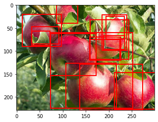

```python
faster_rcnn = fasterrcnn_mobilenet_v3_large_fpn(pretrained=True)
faster_rcnn = faster_rcnn.to(device)
faster_rcnn.eval()
for batch, (X, y) in enumerate(test_loader):
    X, y = to_device(X, device), to_device(y, device)
    pred = faster_rcnn(X)
    print_bboxes(pred, X)
    break
```

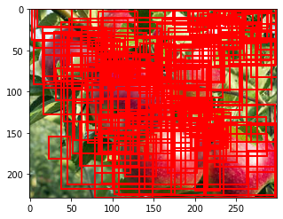

```python
ssd = ssd300_vgg16(pretrained=True)
ssd.eval()
for batch, (X, y) in enumerate(test_loader):
    pred = ssd(X)
    #print(pred)
    print_bboxes(pred, X)
    break
```

```python
evaluate(faster_rcnn, test_loader, device)
```

```
1.2386968908708041e-05
```

Видно, что модель делает случайные предсказывания

### Задание 2.

Обучите детекторы из задания выше на обучающем датасете, оцените качество на тестовом. При необходимости, подберите гиперпараметры - optimizer, lr, weight_decay etc.  
Выполните обучение в двух вариантах: со случайной инициализацией весов и с загрузкой весов уже обученной модели. Сравните качество.

```python
fast_rcnn = fasterrcnn_mobilenet_v3_large_fpn(pretrained=False)
fast_rcnn = fast_rcnn.to(device)
optimizer = torch.optim.SGD(fast_rcnn.parameters(), lr = 0.01)
sch = torch.optim.lr_scheduler.ExponentialLR(optimizer, 0.9)
train_fruit_data = FruitDataset(dataset_path + '/train',
                               transform=torchvision.transforms.Compose(
                                   [torchvision.transforms.ToTensor(),
                                    torchvision.transforms.ConvertImageDtype(torch.float32)]),
                               classific=False)
test_fruit_data = FruitDataset(dataset_path + '/test',
                               transform=torchvision.transforms.Compose(
                                   [torchvision.transforms.ToTensor(),
                                    torchvision.transforms.ConvertImageDtype(torch.float32)]),
                               classific=False)
train_set, val_set = train_test_split(train_fruit_data, test_size=0.2)
tr_loader = DataLoader(train_set, batch_size=2, collate_fn=collate_fn)
val_loader = DataLoader(val_set, batch_size=2, collate_fn=collate_fn)
```

```
Downloading: "https://download.pytorch.org/models/mobilenet_v3_large-8738ca79.pth" to /root/.cache/torch/hub/checkpoints/mobilenet_v3_large-8738ca79.pth
```

```python
train(fast_rcnn, optimizer, tr_loader, val_loader, sch, 20)
```

```
Epoch:  0
AVG LOSSSS:  tensor(0.0025, device='cuda:0', grad_fn=<DivBackward0>)
AUC:  0.6487867568174288
Epoch:  1
AVG LOSSSS:  tensor(0.0026, device='cuda:0', grad_fn=<DivBackward0>)
AUC:  0.6914030310347783
Epoch:  2
AVG LOSSSS:  tensor(0.0024, device='cuda:0', grad_fn=<DivBackward0>)
AUC:  0.6478459998004467
Epoch:  3
AVG LOSSSS:  tensor(0.0024, device='cuda:0', grad_fn=<DivBackward0>)
AUC:  0.648132053408444
Epoch:  4
AVG LOSSSS:  tensor(0.0024, device='cuda:0', grad_fn=<DivBackward0>)
AUC:  0.6622826060215655
Epoch:  5
AVG LOSSSS:  tensor(0.0023, device='cuda:0', grad_fn=<DivBackward0>)
AUC:  0.6529321611813463
Epoch:  6
AVG LOSSSS:  tensor(0.0024, device='cuda:0', grad_fn=<DivBackward0>)
AUC:  0.6590297091167949
Epoch:  7
AVG LOSSSS:  tensor(0.0024, device='cuda:0', grad_fn=<DivBackward0>)
AUC:  0.6601070603615636
Epoch:  8
AVG LOSSSS:  tensor(0.0023, device='cuda:0', grad_fn=<DivBackward0>)
AUC:  0.6712881690461505
Epoch:  9
AVG LOSSSS:  tensor(0.0024, device='cuda:0', grad_fn=<DivBackward0>)
AUC:  0.671352243355625
Epoch:  10
AVG LOSSSS:  tensor(0.0023, device='cuda:0', grad_fn=<DivBackward0>)
AUC:  0.668896963859899
Epoch:  11
AVG LOSSSS:  tensor(0.0023, device='cuda:0', grad_fn=<DivBackward0>)
AUC:  0.6745302291532219
Epoch:  12
AVG LOSSSS:  tensor(0.0023, device='cuda:0', grad_fn=<DivBackward0>)
AUC:  0.7187526184534426
Epoch:  13
AVG LOSSSS:  tensor(0.0024, device='cuda:0', grad_fn=<DivBackward0>)
AUC:  0.7227749432324442
Epoch:  14
AVG LOSSSS:  tensor(0.0024, device='cuda:0', grad_fn=<DivBackward0>)
AUC:  0.7393780649664604
Epoch:  15
AVG LOSSSS:  tensor(0.0024, device='cuda:0', grad_fn=<DivBackward0>)
AUC:  0.743730139816058
Epoch:  16
AVG LOSSSS:  tensor(0.0024, device='cuda:0', grad_fn=<DivBackward0>)
AUC:  0.7449046737337458
Epoch:  17
AVG LOSSSS:  tensor(0.0023, device='cuda:0', grad_fn=<DivBackward0>)
AUC:  0.7374909420421928
Epoch:  18
AVG LOSSSS:  tensor(0.0024, device='cuda:0', grad_fn=<DivBackward0>)
AUC:  0.7413380616434101
Epoch:  19
AVG LOSSSS:  tensor(0.0023, device='cuda:0', grad_fn=<DivBackward0>)
AUC:  0.7421006629978965
```

```python
test_loader = DataLoader(test_fruit_data, batch_size=2, collate_fn=collate_fn)
evaluate(fast_rcnn, test_loader, device)
```

```
0.6955790264140399
```

```python
def num_classes_fast_rcnn(classes, model):
  feat = model.roi_heads.box_predictor.cls_score.in_features
  model.roi_heads.box_predictor = torchvision.models.detection.faster_rcnn.FastRCNNPredictor(feat, classes)
fast_rcnnf_num_2 = fasterrcnn_mobilenet_v3_large_fpn(pretrained=True)
num_classes_fast_rcnn(2, fast_rcnnf_num_2)
fast_rcnnf_num_2 = fast_rcnnf_num_2.to(device)
optimizer = torch.optim.SGD(fast_rcnnf_num_2.parameters(), lr = 0.01)
sch = torch.optim.lr_scheduler.ExponentialLR(optimizer, 0.9)
train(fast_rcnnf_num_2, optimizer, tr_loader, val_loader, sch, 10)
```

```
Epoch:  0
AVG LOSSSS:  tensor(0.0037, device='cuda:0', grad_fn=<DivBackward0>)
AUC:  0.891204432783411
Epoch:  1
AVG LOSSSS:  tensor(0.0028, device='cuda:0', grad_fn=<DivBackward0>)
AUC:  0.8897370516723004
Epoch:  2
AVG LOSSSS:  tensor(0.0029, device='cuda:0', grad_fn=<DivBackward0>)
AUC:  0.9080394670238467
Epoch:  3
AVG LOSSSS:  tensor(0.0022, device='cuda:0', grad_fn=<DivBackward0>)
AUC:  0.908876499999014
Epoch:  4
AVG LOSSSS:  tensor(0.0023, device='cuda:0', grad_fn=<DivBackward0>)
AUC:  0.8808011085095542
Epoch:  5
AVG LOSSSS:  tensor(0.0021, device='cuda:0', grad_fn=<DivBackward0>)
AUC:  0.8934237882787426
Epoch:  6
AVG LOSSSS:  tensor(0.0023, device='cuda:0', grad_fn=<DivBackward0>)
AUC:  0.8985350614037296
Epoch:  7
AVG LOSSSS:  tensor(0.0015, device='cuda:0', grad_fn=<DivBackward0>)
AUC:  0.8951092048971017
Epoch:  8
AVG LOSSSS:  tensor(0.0019, device='cuda:0', grad_fn=<DivBackward0>)
AUC:  0.8797985049744792
Epoch:  9
AVG LOSSSS:  tensor(0.0019, device='cuda:0', grad_fn=<DivBackward0>)
AUC:  0.9003056154770349
```

```python
test_loader = DataLoader(test_fruit_data, batch_size=1, collate_fn=collate_fn)
evaluate(fast_rcnnf_num_2, test_loader, device)
```

```
0.9276276214032473
```

Что и ожидалось у предобученной модели результаты получились лучше

### Задание 3.

- Для лучшей модели оцените, как меняется качество на тестовых данных при изменении порога IoU.
- Также добавьте порог для минимального значения score у предсказанных bounding box'ов, таким образом отсеивая предсказания с низким конфиденсом. Оцените, как меняется качество при изменении порога (порог IoU используйте 0.5).

```python
evaluate(fast_rcnnf_num_2, test_loader, device, iou_threshold=0.4)
```

```
0.9550636955507545
```

```python
evaluate(fast_rcnnf_num_2, test_loader, device, iou_threshold=0.1)
```

```
0.9557744447736412
```

```python
evaluate(fast_rcnnf_num_2, test_loader, device, iou_threshold=0.6)
```

```
0.9123624660515834
```

Вывод: чем ниже iou_treshold тем выше метрики, однако результаты все равно надо проверять

```python
def scores_filter(target: dict, threshold: 0.5):
    target_ = target.copy()
    index = 0
    while index < len(target_['scores']):
      cur_score = target_['scores'][index]
      if cur_score <= threshold:
        break
      index += 1
    target_['scores'] = target_['scores'][: index]
    target_['boxes'] = target_['boxes'][: index]
    target_['labels'] = target_['labels'][: index]
    return target_
```

```python
scores_threshold = 0.3
filters = [(scores_filter, {'threshold': scores_threshold})]
evaluate(fast_rcnnf_num_2, test_loader, device, iou_threshold=0.6, filters=filters)
```

```
0.9006618988760462
```

```python
scores_threshold = 0.8
filters = [(scores_filter, {'threshold': scores_threshold})]
evaluate(fast_rcnnf_num_2, test_loader, device, iou_threshold=0.6, filters=filters)
```

```
0.8619430679934783
```

### Задание 4.

Нарисуйте предсказанные bounding box'ы для любых двух картинок из **тестового** датасета и каких-нибудь картинок из **интернета** (релевантных - где есть эти фрукты - и тех, где этих фруктов нет).

```python
other_images = CustomBoundingDataset(dataset_path + "/other_img/", transform=torchvision.transforms.Compose(
                                   [torchvision.transforms.ToTensor(),
                                    torchvision.transforms.ConvertImageDtype(torch.float32)]), classification=False)
other_images[0].shape
```

```
torch.Size([3, 288, 480])
```

1) Картинка из интернета

2) Картинка из датасета

3) Картинка из датасета

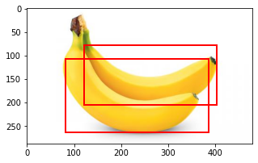

```python
prediction = fast_rcnnf_num_2(other_images[0].reshape([1,3,288,480]).to(device))
print_bboxes(prediction, other_images[0].reshape([1,3,288,480]), conf=0.85)
```

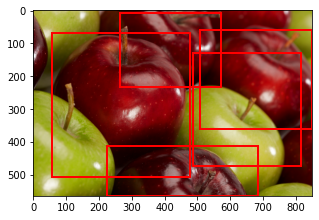

```python
img = test_fruit_data[10][0]
prediction = fast_rcnnf_num_2(img.reshape([1,3,565,850]).to(device))
print_bboxes(prediction, img.reshape([1,3,565,850]), conf=0.85)
```

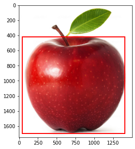

```python
img = test_fruit_data[20][0]
prediction = fast_rcnnf_num_2(img.reshape([1,3, 1749, 1500]).to(device))
print_bboxes(prediction, img.reshape([1,3, 1749, 1500]), conf=0.85)
```

### Задание 5.

Реализуйте и примените Non-maximum Suppression. Оцените (визуально и по метрикам), как его использование влияет на качество детекции.  
**NB:** Чтобы продемонстрировать эффективность применения алгоритма, возможно, нужно будет взять достаточно низкий порог конфиденса.

```python
filters = [(scores_filter, {"threshold" : 0.3}),
           (nms,           {"threshold" : 0.2})]
evaluate(fast_rcnnf_num_2, test_loader, device, filters=filters)
```

```
0.7934954941522776
```

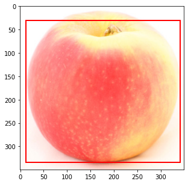

```python
nms_threshold = 0.3
img = test_fruit_data[15][0]
prediction = fast_rcnnf_num_2(img.reshape([1,3, 350, 350]).to(device))
evaluate(fast_rcnnf_num_2, test_loader, device, iou_threshold=0.6, filters=filters)
print_bboxes(prediction, img.reshape([1,3, 350, 350]), conf=0.85)
```

## Часть 2.

*Вес в общей оценке - 0.4*

Выполните задания 2-5 из предыдущей части для случая 3-х классов (как в изначальном датасете).

```python
fruit_test_dataset = FruitDataset(dataset_path + "/test/", transform=torchvision.transforms.Compose(
                                     [torchvision.transforms.ToTensor(),
                                     torchvision.transforms.ConvertImageDtype(torch.float32)]))
print(len(fruit_test_dataset))
fast_rcnnn_num_3 = torchvision.models.detection.fasterrcnn_mobilenet_v3_large_fpn(pretrained=True)
fast_rcnnn_num_3 = fast_rcnnn_num_3.to(device)
test_loader_3 = DataLoader(fruit_test_dataset, batch_size=1, collate_fn=collate_fn)
evaluate(fast_rcnnn_num_3, test_loader_3, device)
```

```
60
```

```
Downloading: "https://download.pytorch.org/models/fasterrcnn_mobilenet_v3_large_fpn-fb6a3cc7.pth" to /root/.cache/torch/hub/checkpoints/fasterrcnn_mobilenet_v3_large_fpn-fb6a3cc7.pth
```

```
0.6710011402398298
```

```python
fruit_train_dataset_3 = FruitDataset(dataset_path + "/train/", transform=torchvision.transforms.Compose(
                                     [torchvision.transforms.ToTensor(),
                                     torchvision.transforms.ConvertImageDtype(torch.float32)]))
fruit_train_num3, fruit_val_num3 = train_test_split(fruit_train_dataset_3, test_size=0.2)
train_loader3 = DataLoader(fruit_train_num3, batch_size=1, collate_fn=collate_fn)
val_loader3 = DataLoader(fruit_val_num3, batch_size=1, collate_fn=collate_fn)
```

```python
fast_rcnnf_model_3 = torchvision.models.detection.fasterrcnn_mobilenet_v3_large_fpn(pretrained=False)
fast_rcnnf_model_3 = fast_rcnnf_model_3.to(device)
optimizer = torch.optim.SGD(fast_rcnnf_model_3.parameters(), lr=0.01)
sch = torch.optim.lr_scheduler.ExponentialLR(optimizer, 0.9)
train(fast_rcnnf_model_3, optimizer, train_loader3, val_loader3, sch, 10)
```

```
Downloading: "https://download.pytorch.org/models/mobilenet_v3_large-8738ca79.pth" to /root/.cache/torch/hub/checkpoints/mobilenet_v3_large-8738ca79.pth
```

```
Epoch:  0
AVG LOSSSS:  tensor(0.0033, device='cuda:0', grad_fn=<DivBackward0>)
AUC:  0.49546032529588724
Epoch:  1
AVG LOSSSS:  tensor(0.0023, device='cuda:0', grad_fn=<DivBackward0>)
AUC:  0.648332997241959
Epoch:  2
AVG LOSSSS:  tensor(0.0015, device='cuda:0', grad_fn=<DivBackward0>)
AUC:  0.6912836305722642
Epoch:  3
AVG LOSSSS:  tensor(0.0014, device='cuda:0', grad_fn=<DivBackward0>)
AUC:  0.752067178147903
Epoch:  4
AVG LOSSSS:  tensor(0.0011, device='cuda:0', grad_fn=<DivBackward0>)
AUC:  0.7512255551474499
Epoch:  5
AVG LOSSSS:  tensor(0.0010, device='cuda:0', grad_fn=<DivBackward0>)
AUC:  0.7820949185896324
Epoch:  6
AVG LOSSSS:  tensor(0.0008, device='cuda:0', grad_fn=<DivBackward0>)
AUC:  0.8025359159245795
Epoch:  7
AVG LOSSSS:  tensor(0.0008, device='cuda:0', grad_fn=<DivBackward0>)
AUC:  0.788550027593018
Epoch:  8
AVG LOSSSS:  tensor(0.0009, device='cuda:0', grad_fn=<DivBackward0>)
AUC:  0.7917749783164573
Epoch:  9
AVG LOSSSS:  tensor(0.0010, device='cuda:0', grad_fn=<DivBackward0>)
AUC:  0.8236992278799038
```

```python
train(fast_rcnnf_model_3, optimizer, train_loader3, val_loader3, sch, 10)
```

```
Epoch:  0
AVG LOSSSS:  tensor(0.0025, device='cuda:0', grad_fn=<DivBackward0>)
AUC:  0.7296519036770894
Epoch:  1
AVG LOSSSS:  tensor(0.0026, device='cuda:0', grad_fn=<DivBackward0>)
AUC:  0.7619899573026631
Epoch:  2
AVG LOSSSS:  tensor(0.0026, device='cuda:0', grad_fn=<DivBackward0>)
AUC:  0.7913885050323305
Epoch:  3
AVG LOSSSS:  tensor(0.0024, device='cuda:0', grad_fn=<DivBackward0>)
AUC:  0.7975408080852299
Epoch:  4
AVG LOSSSS:  tensor(0.0021, device='cuda:0', grad_fn=<DivBackward0>)
AUC:  0.809764645842558
Epoch:  5
AVG LOSSSS:  tensor(0.0022, device='cuda:0', grad_fn=<DivBackward0>)
AUC:  0.802681118408149
Epoch:  6
AVG LOSSSS:  tensor(0.0025, device='cuda:0', grad_fn=<DivBackward0>)
AUC:  0.8208042899053648
Epoch:  7
AVG LOSSSS:  tensor(0.0020, device='cuda:0', grad_fn=<DivBackward0>)
AUC:  0.8158945256619198
Epoch:  8
AVG LOSSSS:  tensor(0.0019, device='cuda:0', grad_fn=<DivBackward0>)
AUC:  0.7796515426249371
Epoch:  9
AVG LOSSSS:  tensor(0.0020, device='cuda:0', grad_fn=<DivBackward0>)
AUC:  0.7906596230558154
```

```python
evaluate(fast_rcnnf_model_3, test_loader_3, device)
```

```
0.7631545589593955
```

[figure not shown]

```python
img = fruit_test_dataset[26][0]
prediction = fast_rcnnf_model_3(img.reshape([1,3, 1024, 1009]).to(device))
print_bboxes(prediction, img.reshape([1,3, 1024, 1009]), conf=0.85)
```

```python
retina = retinanet_resnet50_fpn(pretrained=True)
retina = retina.to(device)

optimizer = torch.optim.SGD(retina.parameters(), lr=0.001)
scheduler = torch.optim.lr_scheduler.ExponentialLR(optimizer, 0.9)
train(retina, optimizer, train_loader3, val_loader3, sch, 10)
```

```
Downloading: "https://download.pytorch.org/models/retinanet_resnet50_fpn_coco-eeacb38b.pth" to /root/.cache/torch/hub/checkpoints/retinanet_resnet50_fpn_coco-eeacb38b.pth
```

```
Epoch:  0
AVG LOSSSS:  tensor(0.0006, device='cuda:0', grad_fn=<DivBackward0>)
AUC:  0.8725367954164193
Epoch:  1
AVG LOSSSS:  tensor(0.0004, device='cuda:0', grad_fn=<DivBackward0>)
AUC:  0.8971992121815743
Epoch:  2
AVG LOSSSS:  tensor(0.0004, device='cuda:0', grad_fn=<DivBackward0>)
AUC:  0.897099100651436
Epoch:  3
AVG LOSSSS:  tensor(0.0003, device='cuda:0', grad_fn=<DivBackward0>)
AUC:  0.9056595425481628
Epoch:  4
AVG LOSSSS:  tensor(0.0003, device='cuda:0', grad_fn=<DivBackward0>)
AUC:  0.9049902891531058
Epoch:  5
AVG LOSSSS:  tensor(0.0003, device='cuda:0', grad_fn=<DivBackward0>)
AUC:  0.9014185513244233
Epoch:  6
AVG LOSSSS:  tensor(0.0003, device='cuda:0', grad_fn=<DivBackward0>)
AUC:  0.911088798732801
Epoch:  7
AVG LOSSSS:  tensor(0.0002, device='cuda:0', grad_fn=<DivBackward0>)
AUC:  0.904811504393273
Epoch:  8
AVG LOSSSS:  tensor(0.0002, device='cuda:0', grad_fn=<DivBackward0>)
AUC:  0.9085403201733812
Epoch:  9
AVG LOSSSS:  tensor(0.0002, device='cuda:0', grad_fn=<DivBackward0>)
AUC:  0.9053199407316901
```

```python
evaluate(retina, test_loader_3, device)
```

```
0.8721149981799751
```

```python
ssd = ssd300_vgg16(pretrained=False)
num_anchors = ssd.anchor_generator.num_anchors_per_location()
out_channels = det_utils.retrieve_out_channels(ssd.backbone, (300, 300))
ssd.head.classification_head = models.detection.ssd.SSDClassificationHead(
                in_channels=out_channels, num_anchors=num_anchors, num_classes=4)
ssd = ssd300_vgg16(pretrained=True)
ssd = ssd.to(device)
optimizer = torch.optim.SGD(ssd.parameters(), lr=0.001)
sch = torch.optim.lr_scheduler.ExponentialLR(optimizer, 0.9)
train(ssd, optimizer, train_loader3, val_loader3, sch, 10)
```

```
Epoch:  0
AVG LOSSSS:  tensor(0.0151, device='cuda:0', grad_fn=<DivBackward0>)
AUC:  0.7852992451948938
Epoch:  1
AVG LOSSSS:  tensor(0.0074, device='cuda:0', grad_fn=<DivBackward0>)
AUC:  0.8354908690411023
Epoch:  2
AVG LOSSSS:  tensor(0.0052, device='cuda:0', grad_fn=<DivBackward0>)
AUC:  0.8959218017654222
Epoch:  3
AVG LOSSSS:  tensor(0.0063, device='cuda:0', grad_fn=<DivBackward0>)
AUC:  0.8783870755182798
Epoch:  4
AVG LOSSSS:  tensor(0.0040, device='cuda:0', grad_fn=<DivBackward0>)
AUC:  0.8820805852374335
Epoch:  5
AVG LOSSSS:  tensor(0.0037, device='cuda:0', grad_fn=<DivBackward0>)
AUC:  0.9011139650649095
Epoch:  6
AVG LOSSSS:  tensor(0.0031, device='cuda:0', grad_fn=<DivBackward0>)
AUC:  0.8935641029326665
Epoch:  7
AVG LOSSSS:  tensor(0.0027, device='cuda:0', grad_fn=<DivBackward0>)
AUC:  0.9012174361223094
Epoch:  8
AVG LOSSSS:  tensor(0.0024, device='cuda:0', grad_fn=<DivBackward0>)
AUC:  0.9130982934388617
Epoch:  9
AVG LOSSSS:  tensor(0.0023, device='cuda:0', grad_fn=<DivBackward0>)
AUC:  0.9161801148595485
```

```python
evaluate(ssd, test_loader_3, device)
```

```
0.8865629680184165
```

Retina

1) Картинка из интернета

2) Картинка из датасета

```
Detection:
0) banana
1) apple
2) apple
3) banana
4) apple
5) banana
6) banana
7) banana
8) apple
9) apple
10) None
11) banana
12) banana
13) banana
14) None
15) orange
```

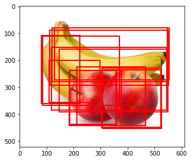

```python
prediction = retina(other_images[1].reshape([1,3,521,612]).to(device))
labels = [_, 'apple', 'orange', 'banana']
scores_threshold = 0.3
filters = [(scores_filter, {"threshold" : scores_threshold})]
print_bboxes(prediction, other_images[1].reshape([1,3,521,612]),
                     filters=filters, labels=labels)
```

```
Detection:
0) apple
1) apple
2) banana
3) banana
4) apple
```

[figure not shown]

```python
img = fruit_test_dataset[6][0]
shape = [1, img.shape[0], img.shape[1], img.shape[2]]
print_bboxes(prediction, img.reshape(shape),
                     filters=filters, labels=labels)
```

1) Картинка из интернета

2) Картинка из датасета

```
Detection:
0) apple
1) apple
2) banana
3) banana
4) apple
```

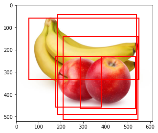

```python
prediction_ssd = ssd(other_images[1].reshape([1,3,521,612]).to(device))
labels = [_, 'apple', 'orange', 'banana']
scores_threshold = 0.3
filters = [(scores_filter, {"threshold" : scores_threshold})]
print_bboxes(prediction, other_images[1].reshape([1,3,521,612]),
                     filters=filters, labels=labels)
```

```
Detection:
0) apple
1) banana
2) apple
3) banana
4) banana
5) banana
6) banana
```

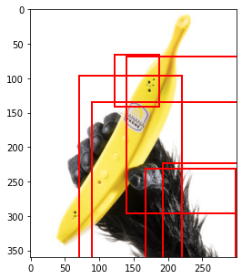

```python
img = fruit_test_dataset[19][0]
shape = [1, img.shape[0], img.shape[1], img.shape[2]]
print_bboxes(prediction_ssd, img.reshape(shape),
                     filters=filters, labels=labels)
```

1) Картинка из интернета

2) Картинка из датасета

```
Detection:
0) apple
1) apple
2) banana
3) banana
4) apple
```

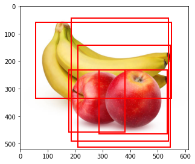

```python
prediction_rcnn = fast_rcnnf_model_3(other_images[1].reshape([1,3,521,612]).to(device))
labels = [_, 'apple', 'orange', 'banana']
scores_threshold = 0.3
filters = [(scores_filter, {"threshold" : scores_threshold})]
print_bboxes(prediction, other_images[1].reshape([1,3,521,612]),
                     filters=filters, labels=labels)
```

```
Detection:
0) apple
1) apple
2) banana
3) banana
4) apple
```

[figure not shown]

```python
img = fruit_test_dataset[19][0]
shape = [1, img.shape[0], img.shape[1], img.shape[2]]
print_bboxes(prediction_rcnn, img.reshape(shape),
                     filters=filters, labels=labels)
```

## Часть 3.

*Вес в общей оценке - 0.2*

Обучите модель для object detection для трех классов на **обучающем** датасете и добейтесь PR AUC не менее **0.91** на **тестовом**.  
Баллы за задание вычисляются по формуле: **min(2, 2 * Ваш auc / 0.91)**.

Fast - RCNNF NOT PRETRAINED = 0.763

RETINA PRETRAINED = 0.872

SSD PRETRAINED = 0.886